# Regression Homework

Andrew Vandenberg

April 24, 2021

# 1 Import the `mlbattendance2015` data set from project 2 into R.

```r
library(tidyverse)
library(readxl)
mlb <- read_excel("mlbattendance2015.xlsx")
```

# 2 Build a regression model to predict average attendance from Winning Percentage (`Winpct`). Also provide a graphical summary of the relationship.

```r
avg_att <- lm(avgattendance ~ winpct, mlb)
avg_att
```

```
##
## Call:
## lm(formula = avgattendance ~ winpct, data = mlb)
##
## Coefficients:
## (Intercept)       winpct
##     -2054.6        619.1
```

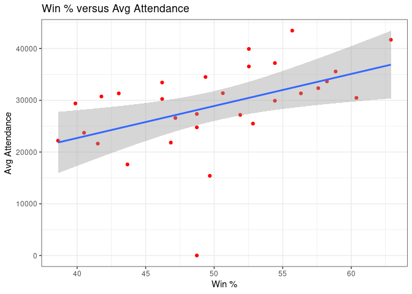

```r
ggplot(avg_att, aes(x = winpct, y = avgattendance)) +
  geom_point(color = "red") +
  geom_smooth(method = "lm") +
  labs(x = "Win %", y = "Avg Attendance", title = "Win % versus Avg Attendance") +
  theme_bw()
```

```r
summary(avg_att)
```

```
##
## Call:
## lm(formula = avgattendance ~ winpct, data = mlb)
##
## Residuals:
##      Min       1Q   Median       3Q      Max
## -28101.7  -2670.1      6.8   5883.8  11039.6
##
## Coefficients:
##             Estimate Std. Error t value Pr(>|t|)
## (Intercept)  -2054.6    11166.8  -0.184  0.85534
## winpct         619.1      221.6   2.794  0.00928 **
## ---
## Signif. codes:  0 '***' 0.001 '**' 0.01 '*' 0.05 '.' 0.1 ' ' 1
##
## Residual standard error: 7730 on 28 degrees of freedom
## Multiple R-squared:  0.2181, Adjusted R-squared:  0.1901
## F-statistic: 7.808 on 1 and 28 DF,  p-value: 0.009281
```

# 3 Next, add League as a predictor to the previous model, in a parallel lines model.

```r
mlb$League = factor(mlb$League)

avg_att2 <- lm(avgattendance ~ winpct + League, mlb)
avg_att2
```

```
##
## Call:
## lm(formula = avgattendance ~ winpct + League, data = mlb)
##
## Coefficients:
##    (Intercept)          winpct  LeagueNational
##        -6609.3           660.7          4950.8
```

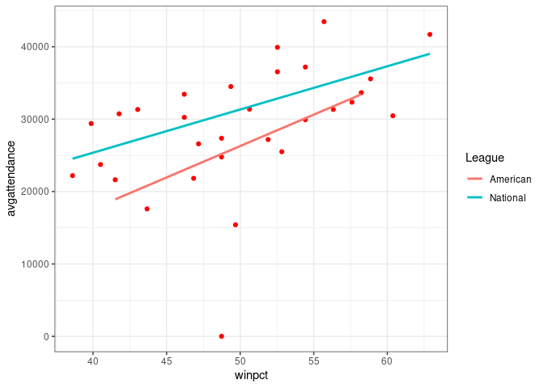

```r
ggplot(avg_att2, aes(x = winpct, y = avgattendance, color = League)) +
  geom_point(color = "red") +
  geom_smooth(method = "lm", se = FALSE) +
  theme_bw()
```

```r
summary(avg_att2)
```

```
##
## Call:
## lm(formula = avgattendance ~ winpct + League, data = mlb)
##
## Residuals:
##      Min       1Q   Median       3Q      Max
## -25573.8  -2296.0    857.8   4671.3   9521.4
##
## Coefficients:
##                Estimate Std. Error t value Pr(>|t|)
## (Intercept)     -6609.3    11026.2  -0.599  0.55389
## winpct            660.7      214.3   3.084  0.00467 **
## LeagueNational   4950.8     2729.6   1.814  0.08085 .
## ---
## Signif. codes:  0 '***' 0.001 '**' 0.01 '*' 0.05 '.' 0.1 ' ' 1
##
## Residual standard error: 7432 on 27 degrees of freedom
## Multiple R-squared:  0.303,  Adjusted R-squared:  0.2513
## F-statistic: 5.868 on 2 and 27 DF,  p-value: 0.007653
```

# 4 Finally, add potential interaction between League and Winning Percentage as a predictor, creating a possible non-parallel lines model.

```r
avg_att3 <- lm(avgattendance ~ winpct + League + winpct:League, mlb)
avg_att3
```

```
##
## Call:
## lm(formula = avgattendance ~ winpct + League + winpct:League,
##     data = mlb)
##
## Coefficients:
##           (Intercept)                 winpct         LeagueNational
##              -17069.6                  867.1                18555.3
## winpct:LeagueNational
##                -270.2
```

```r
summary(avg_att3)
```

```
##
## Call:
## lm(formula = avgattendance ~ winpct + League + winpct:League,
##     data = mlb)
##
## Residuals:
##      Min       1Q   Median       3Q      Max
## -25172.5  -2231.2     10.5   4144.8  10445.3
##
## Coefficients:
##                       Estimate Std. Error t value Pr(>|t|)
## (Intercept)           -17069.6    22739.0  -0.751   0.4596
## winpct                   867.1      447.0   1.940   0.0633 .
## LeagueNational         18555.3    25903.2   0.716   0.4802
## winpct:LeagueNational   -270.2      511.4  -0.528   0.6018
## ---
## Signif. codes:  0 '***' 0.001 '**' 0.01 '*' 0.05 '.' 0.1 ' ' 1
##
## Residual standard error: 7534 on 26 degrees of freedom
## Multiple R-squared:  0.3104, Adjusted R-squared:  0.2308
## F-statistic: 3.901 on 3 and 26 DF,  p-value: 0.01998
```

# 5 Provide a graph of the data that incorporates both winning percentage and league as predictors and avg attendance as the response.

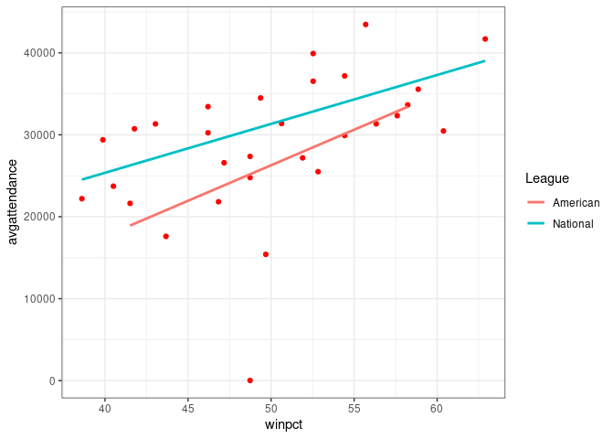

```r
ggplot(avg_att2, aes(x = winpct, y = avgattendance, color = League)) +
  geom_point(color = "red") +
  geom_smooth(method = "lm", se = FALSE) +
  theme_bw()
```

# 6 Which of the models in (2), (3), and (4) do you think is the best? Clearly justify your answer.

The model from question 3 (`avg_att2`) is the best model because it has the highest adjusted $R^2$ value (0.25 vs 0.19 (`avg_att`) and 0.23 (`avg_att3`)).

| Model | Adjusted $R^2$ |
| --- | --- |
| `avg_att` | 0.19 |
| `avg_att2` | 0.25 |
| `avg_att3` | 0.23 |

# 7 Predict average attendance for an American League team with a 60% winning percentage, and for a National League Team with a 50% winning percentage based upon your best model from steps (2), (3), (4).

```r
newdata <- tibble(League = c("National"), winpct = c(50))
newdata2 <- tibble(League = c("American"), winpct = c(60))

National_mod1 <- predict(avg_att, newdata, se.fit = FALSE)
National_mod2 <- predict(avg_att2, newdata, se.fit = FALSE)
National_mod3 <- predict(avg_att3, newdata, se.fit = FALSE)


American_mod1 <- predict(avg_att, newdata2, se.fit = FALSE)
American_mod2 <- predict(avg_att2, newdata2, se.fit = FALSE)
American_mod3 <- predict(avg_att3, newdata2, se.fit = FALSE)
```

| Model | Prediction Value |
| --- | --- |
| `National_mod1` | 28900.82 |
| `National_mod2` | 31376.33 |
| `National_mod3` | 31332.66 |
| `American_mod1` | 35091.91 |
| `American_mod2` | 33032.54 |
| `American_mod3` | 34956.55 |